# Peer2

Fideborios

Friday, February 20, 2015

First of all we are loading the necessary library ‘Knitr’

```r
library(knitr)
```

Second step is loading the data

```r
data(mtcars)
```

Lets take a look

```r
head(mtcars)
```

```
##                    mpg cyl disp  hp drat    wt  qsec vs am gear carb
## Mazda RX4         21.0   6  160 110 3.90 2.620 16.46  0  1    4    4
## Mazda RX4 Wag     21.0   6  160 110 3.90 2.875 17.02  0  1    4    4
## Datsun 710        22.8   4  108  93 3.85 2.320 18.61  1  1    4    1
## Hornet 4 Drive    21.4   6  258 110 3.08 3.215 19.44  1  0    3    1
## Hornet Sportabout 18.7   8  360 175 3.15 3.440 17.02  0  0    3    2
## Valiant           18.1   6  225 105 2.76 3.460 20.22  1  0    3    1
```

```r
levels(mtcars$am)= c("Auto", "Manual")
```

Our concern is if automatic transmission consumps more fuel than manual or the opposite.

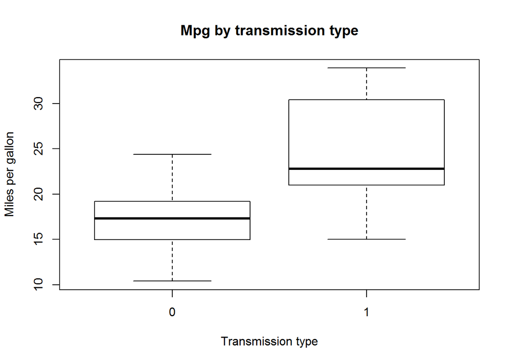

##### As we can see in the above Boxplot the manual transmission consumes fewer fuel

Lets observe the statistical difference. A good way to compare 2 means is the t-test

```r
with(mtcars, t.test(mpg[am == 0], mpg[am == 1]))
```

```
##
##  Welch Two Sample t-test
##
## data:  mpg[am == 0] and mpg[am == 1]
## t = -3.7671, df = 18.332, p-value = 0.001374
## alternative hypothesis: true difference in means is not equal to 0
## 95 percent confidence interval:
##  -11.280194  -3.209684
## sample estimates:
## mean of x mean of y
##  17.14737  24.39231
```

Next step is to have a linear model with the am variable only

```
##
## Call:
## lm(formula = mpg ~ am, data = mtcars)
##
## Coefficients:
## (Intercept)           am
##      17.147        7.245
```

```
##
## Call:
## lm(formula = mpg ~ cyl + disp + hp + drat + wt + qsec + am +
##     gear + carb, data = mtcars)
##
## Coefficients:
## (Intercept)          cyl         disp           hp         drat
##    12.04177     -0.16205      0.01307     -0.02059      0.79446
##          wt         qsec           am         gear         carb
##    -3.73956      0.86134      2.45510      0.66524     -0.21102
```

When we insert all the variables we observe that the coefficient lowers. This means that there are highly correlated other variables that can explain the variability of the mpg

```r
cor(mtcars[1:8],mtcars$am, use = "everything",
    method = "spearman")
```

```
##            [,1]
## mpg   0.5620057
## cyl  -0.5220712
## disp -0.6240677
## hp   -0.3623276
## drat  0.6865708
## wt   -0.7377126
## qsec -0.2033321
## vs    0.1683451
```

As we can see there are many high correlations.

Using a Stepwise Regression

```r
model.all = lm(mpg ~ ., data = mtcars)
n = nrow(mtcars)

model = step(model.all,
             direction ="both",  # other choices "both" , "forward" #
             k = log(n) ) #(AIC = - 2*log L + k*df) if k=2 AIC, if k=log(n) BIC#
```

We find the best fitting model.

```r
summary(model)
```

```
##
## Call:
## lm(formula = mpg ~ wt + qsec + am, data = mtcars)
##
## Residuals:
##     Min      1Q  Median      3Q     Max
## -3.4811 -1.5555 -0.7257  1.4110  4.6610
##
## Coefficients:
##             Estimate Std. Error t value Pr(>|t|)
## (Intercept)   9.6178     6.9596   1.382 0.177915
## wt           -3.9165     0.7112  -5.507 6.95e-06 ***
## qsec          1.2259     0.2887   4.247 0.000216 ***
## am            2.9358     1.4109   2.081 0.046716 *
## ---
## Signif. codes:  0 '***' 0.001 '**' 0.01 '*' 0.05 '.' 0.1 ' ' 1
##
## Residual standard error: 2.459 on 28 degrees of freedom
## Multiple R-squared:  0.8497, Adjusted R-squared:  0.8336
## F-statistic: 52.75 on 3 and 28 DF,  p-value: 1.21e-11
```

We can write it as : ######MPG= 9.6178 -3.9165*wt + 1.2259*qsec + 2.9358*am

```r
mean(model$residuals)
```

```
## [1] 5.20417e-17
```

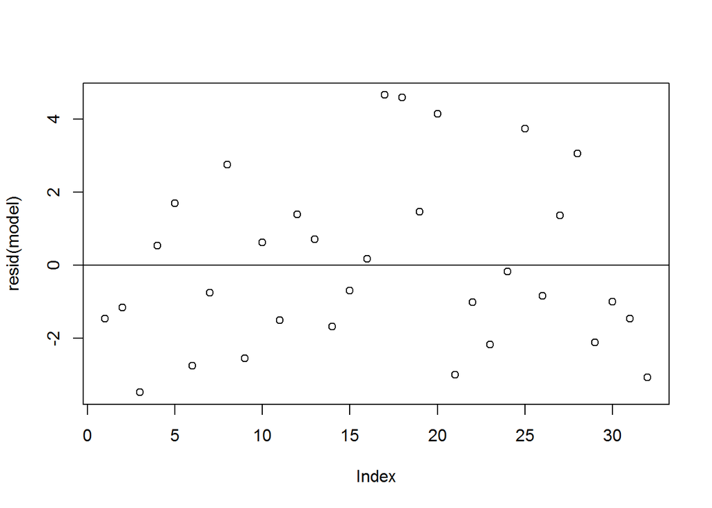

```r
plot(resid(model))
abline(0,0)
```